# Estimation of survival and productivity using capture-recapture and generalized linear models

January 2022

# 1 Partie 1 : Estimation de la survie, exemple du cincle plongeur

## 1.1 Premiers modèles avec des effets temps

On charge les packages `RMark` et `R2ucare`, ce dernier servant à tester les hypothèses des modèles de capture-recapture en population ouverte.

```r
library(RMark)
library(R2ucare)
```

Les données.

```r
cincle <- convert.inp("dat/cincle-plongeur.inp")
```

On jette un coup d’oeil.

```r
head(cincle)
```

|  | ch | freq |
| --- | --- | --- |
| 1 | 0000010 | 23 |
| 2 | 0000011 | 23 |
| 3 | 0000100 | 16 |
| 4 | 0000110 | 9 |
| 5 | 0000111 | 16 |
| 6 | 0001000 | 16 |

On prépare les données.

```r
cincle.proc <- process.data(cincle,
                              begin.time = 1,
                              model = "CJS")
cincle.ddl <- make.design.data(cincle.proc)
```

On inspecte la structure pour la survie.

```r
head(cincle.ddl$Phi)
```

|  | par.index | model.index | group | cohort | age | time | occ.cohort | Cohort | Age | Time |
| --- | --- | --- | --- | --- | --- | --- | --- | --- | --- | --- |
| 1 | 1 | 1 | 1 | 1 | 0 | 1 | 1 | 0 | 0 | 0 |
| 2 | 2 | 2 | 1 | 1 | 1 | 2 | 1 | 0 | 1 | 1 |
| 3 | 3 | 3 | 1 | 1 | 2 | 3 | 1 | 0 | 2 | 2 |
| 4 | 4 | 4 | 1 | 1 | 3 | 4 | 1 | 0 | 3 | 3 |
| 5 | 5 | 5 | 1 | 1 | 4 | 5 | 1 | 0 | 4 | 4 |
| 6 | 6 | 6 | 1 | 1 | 5 | 6 | 1 | 0 | 5 | 5 |

Et la détection.

```r
head(cincle.ddl$p)
```

|  | par.index | model.index | group | cohort | age | time | occ.cohort | Cohort | Age | Time |
| --- | --- | --- | --- | --- | --- | --- | --- | --- | --- | --- |
| 1 | 1 | 22 | 1 | 1 | 1 | 2 | 1 | 0 | 1 | 0 |
| 2 | 2 | 23 | 1 | 1 | 2 | 3 | 1 | 0 | 2 | 1 |
| 3 | 3 | 24 | 1 | 1 | 3 | 4 | 1 | 0 | 3 | 2 |
| 4 | 4 | 25 | 1 | 1 | 4 | 5 | 1 | 0 | 4 | 3 |
| 5 | 5 | 26 | 1 | 1 | 5 | 6 | 1 | 0 | 5 | 4 |
| 6 | 6 | 27 | 1 | 1 | 6 | 7 | 1 | 0 | 6 | 5 |

On spécifie les effets sur les paramètres.

```r
phit <- list(formula=~time)
phi <- list(formula=~1)
pt <- list(formula=~time)
p <- list(formula=~1)
```

On ajuste le modèle Cormack-Jolly-Seber (CJS).

```r
cjs.cincle <- mark(cincle.proc,
                   cincle.ddl,
                   model.parameters = list(Phi = phit, p = pt))
```

```
##
## Output summary for CJS model
## Name : Phi(~time)p(~time)
##
## Npar :  12  (unadjusted=11)
## -2lnL:  656.9502
## AICc :  681.7057  (unadjusted=679.58789)
##
## Beta
##                   estimate        se        lcl        ucl
## Phi:(Intercept)  0.9354603 0.7685249 -0.5708486  2.4417692
## Phi:time2       -1.1982795 0.8706726 -2.9047979  0.5082389
## Phi:time3       -1.0228340 0.8049171 -2.6004716  0.5548037
## Phi:time4       -0.4198634 0.8091508 -2.0057990  1.1660723
## Phi:time5       -0.5361023 0.8031459 -2.1102683  1.0380637
## Phi:time6        0.2481427 0.0000000  0.2481427  0.2481427
## p:(Intercept)    0.8292790 0.7837352 -0.7068421  2.3654001
## p:time3          1.6556275 1.2913769 -0.8754713  4.1867264
## p:time4          1.5220965 1.0729145 -0.5808160  3.6250089
## p:time5          1.3767452 0.9884809 -0.5606775  3.3141679
## p:time6          1.7950938 1.0688774 -0.2999059  3.8900936
## p:time7         -0.0147594 0.0000000 -0.0147594 -0.0147594
##
##
## Real Parameter Phi
##
##           1         2         3         4         5        6
## 1 0.7181817 0.4346708 0.4781705 0.6261176 0.5985334 0.765595
## 2           0.4346708 0.4781705 0.6261176 0.5985334 0.765595
## 3                     0.4781705 0.6261176 0.5985334 0.765595
## 4                               0.6261176 0.5985334 0.765595
## 5                                         0.5985334 0.765595
## 6                                                   0.765595
##
##
## Real Parameter p
##
##           2         3         4         5         6         7
## 1 0.6962025 0.9230769 0.9130435 0.9007892 0.9324138 0.6930718
## 2           0.9230769 0.9130435 0.9007892 0.9324138 0.6930718
## 3                     0.9130435 0.9007892 0.9324138 0.6930718
## 4                               0.9007892 0.9324138 0.6930718
## 5                                         0.9324138 0.6930718
## 6                                                   0.6930718
```

Inspectons les résultats.

```r
cjs.cincle$results$real
```

|  | estimate | se | lcl | ucl | fixed | note |
| --- | --- | --- | --- | --- | --- | --- |
| Phi g1 c1 a0 t1 | 0.7181817 | 0.1555469 | 0.3610410 | 0.9199575 |  |  |
| Phi g1 c1 a1 t2 | 0.4346708 | 0.0688290 | 0.3075048 | 0.5710588 |  |  |
| Phi g1 c1 a2 t3 | 0.4781705 | 0.0597091 | 0.3643838 | 0.5942685 |  |  |
| Phi g1 c1 a3 t4 | 0.6261176 | 0.0592655 | 0.5048460 | 0.7333741 |  |  |
| Phi g1 c1 a4 t5 | 0.5985334 | 0.0560517 | 0.4855434 | 0.7019411 |  |  |
| Phi g1 c1 a5 t6 | 0.7655950 | 0.0000000 | 0.7655950 | 0.7655950 |  |  |
| p g1 c1 a1 t2 | 0.6962025 | 0.1657636 | 0.3302970 | 0.9141506 |  |  |
| p g1 c1 a2 t3 | 0.9230769 | 0.0728777 | 0.6161503 | 0.9889758 |  |  |
| p g1 c1 a3 t4 | 0.9130435 | 0.0581758 | 0.7140650 | 0.9778505 |  |  |
| p g1 c1 a4 t5 | 0.9007892 | 0.0538329 | 0.7360177 | 0.9672855 |  |  |

[output cut: 2 more lines]

Les PIM pour CJS.

```r
PIMS(cjs.cincle,"Phi")
```

```
## group = Group 1
##    1  2  3  4  5  6
## 1  1  2  3  4  5  6
## 2     2  3  4  5  6
## 3        3  4  5  6
## 4           4  5  6
## 5              5  6
## 6                 6
```

On fait tourner le modèle avec paramètres constants.

```r
phip.cincle <- mark(cincle.proc,
                    cincle.ddl,
                    model.parameters = list(Phi = phi, p = p))
```

```
##
## Output summary for CJS model
## Name : Phi(~1)p(~1)
##
## Npar :  2
## -2lnL:  666.8377
## AICc :  670.866
##
## Beta
##                  estimate        se       lcl       ucl
## Phi:(Intercept) 0.2421484 0.1020127 0.0422035 0.4420933
## p:(Intercept)   2.2262659 0.3251093 1.5890516 2.8634802
##
##
## Real Parameter Phi
##
##          1        2        3        4        5        6
## 1 0.560243 0.560243 0.560243 0.560243 0.560243 0.560243
## 2          0.560243 0.560243 0.560243 0.560243 0.560243
## 3                   0.560243 0.560243 0.560243 0.560243
## 4                            0.560243 0.560243 0.560243
## 5                                     0.560243 0.560243
## 6                                              0.560243
##
##
## Real Parameter p
##
##           2         3         4         5         6         7
## 1 0.9025835 0.9025835 0.9025835 0.9025835 0.9025835 0.9025835
## 2           0.9025835 0.9025835 0.9025835 0.9025835 0.9025835
## 3                     0.9025835 0.9025835 0.9025835 0.9025835
## 4                               0.9025835 0.9025835 0.9025835
## 5                                         0.9025835 0.9025835
## 6                                                   0.9025835
```

Les résultats.

```r
phip.cincle$results$real
```

|  | estimate | se | lcl | ucl | fixed | note |
| --- | --- | --- | --- | --- | --- | --- |
| Phi g1 c1 a0 t1 | 0.5602430 | 0.0251330 | 0.5105493 | 0.6087577 |  |  |
| p g1 c1 a1 t2 | 0.9025835 | 0.0285857 | 0.8304826 | 0.9460113 |  |  |

Les PIM.

```r
PIMS(phip.cincle,"Phi")
```

```
## group = Group 1
##    1  2  3  4  5  6
## 1  1  1  1  1  1  1
## 2     1  1  1  1  1
## 3        1  1  1  1
## 4           1  1  1
## 5              1  1
## 6                 1
```

```r
PIMS(phip.cincle,"p")
```

```
## group = Group 1
##    2  3  4  5  6  7
## 1  2  2  2  2  2  2
## 2     2  2  2  2  2
## 3        2  2  2  2
## 4           2  2  2
## 5              2  2
## 6                 2
```

On considère deux autres modèles, avec l’effet temps sur la survie mais pas sur la détection, et inversément.

```r
phitp.cincle <- mark(cincle.proc,
                    cincle.ddl,
                    model.parameters = list(Phi = phit, p = p))
```

```
##
## Output summary for CJS model
## Name : Phi(~time)p(~1)
##
## Npar :  7
## -2lnL:  659.7301
## AICc :  673.998
##
## Beta
##                   estimate        se        lcl       ucl
## Phi:(Intercept)  0.5143912 0.4767795 -0.4200966 1.4488789
## Phi:time2       -0.6981412 0.5537190 -1.7834305 0.3871481
## Phi:time3       -0.6009364 0.5300990 -1.6399303 0.4380576
## Phi:time4       -0.0061064 0.5334602 -1.0516883 1.0394756
## Phi:time5       -0.0757118 0.5276494 -1.1099046 0.9584810
## Phi:time6       -0.1780634 0.5265641 -1.2101292 0.8540024
## p:(Intercept)    2.2203956 0.3288850  1.5757810 2.8650102
##
##
## Real Parameter Phi
##
##           1         2         3         4         5         6
## 1 0.6258353 0.4541913 0.4783772 0.6244043 0.6079443 0.5832982
## 2           0.4541913 0.4783772 0.6244043 0.6079443 0.5832982
## 3                     0.4783772 0.6244043 0.6079443 0.5832982
## 4                               0.6244043 0.6079443 0.5832982
## 5                                         0.6079443 0.5832982
## 6                                                   0.5832982
##
##
## Real Parameter p
##
##           2         3         4         5         6         7
## 1 0.9020661 0.9020661 0.9020661 0.9020661 0.9020661 0.9020661
## 2           0.9020661 0.9020661 0.9020661 0.9020661 0.9020661
## 3                     0.9020661 0.9020661 0.9020661 0.9020661
## 4                               0.9020661 0.9020661 0.9020661
## 5                                         0.9020661 0.9020661
## 6                                                   0.9020661
```

```r
phipt.cincle <- mark(cincle.proc,
                    cincle.ddl,
                    model.parameters = list(Phi = phi, p = pt))
```

```
##
## Output summary for CJS model
## Name : Phi(~1)p(~time)
##
## Npar :  7
## -2lnL:  664.4802
## AICc :  678.7481
##
## Beta
##                  estimate        se        lcl       ucl
## Phi:(Intercept) 0.2131641 0.1121136 -0.0065785 0.4329066
## p:(Intercept)   1.2955246 0.7437246 -0.1621757 2.7532250
## p:time3         0.8005304 1.1635514 -1.4800304 3.0810913
## p:time4         0.6512773 1.0018582 -1.3123648 2.6149193
## p:time5         0.9977282 0.9454494 -0.8553527 2.8508091
## p:time6         1.4658876 1.0304008 -0.5536981 3.4854733
## p:time7         1.9900724 3.0642115 -4.0157822 7.9959270
##
##
## Real Parameter Phi
##
##           1         2         3         4         5         6
## 1 0.5530901 0.5530901 0.5530901 0.5530901 0.5530901 0.5530901
## 2           0.5530901 0.5530901 0.5530901 0.5530901 0.5530901
## 3                     0.5530901 0.5530901 0.5530901 0.5530901
## 4                               0.5530901 0.5530901 0.5530901
## 5                                         0.5530901 0.5530901
## 6                                                   0.5530901
##
##
## Real Parameter p
##
##           2         3         4         5         6         7
## 1 0.7850808 0.8905192 0.8750975 0.9083167 0.9405546 0.9639314
## 2           0.8905192 0.8750975 0.9083167 0.9405546 0.9639314
## 3                     0.8750975 0.9083167 0.9405546 0.9639314
## 4                               0.9083167 0.9405546 0.9639314
## 5                                         0.9405546 0.9639314
## 6                                                   0.9639314
```

On affiche la sélection de modèles.

```r
collect.models()
```

```
##                model npar     AICc DeltaAICc      weight Deviance
## 2       Phi(~1)p(~1)    2 670.8660  0.000000 0.811204642 58.15788
## 4    Phi(~time)p(~1)    7 673.9980  3.132004 0.169443317 51.05031
## 3    Phi(~1)p(~time)    7 678.7481  7.882084 0.015760053 55.80039
## 1 Phi(~time)p(~time)   12 681.7057 10.839629 0.003591988 48.27043
```

On a 7 occasions de capture, donc 6 paramètres de survie. La première année de capture dans le jeu de données est 1981, alors on peut estimer la survie entre 1981 et 1982, entre 1982 et 1983 etc. Une inondation eut lieu en 1982 et 1983, avec un effet possible sur la survie. On va comparer les modèles précédents à un modèle incorporant un effet inondation sur les survies sur les intervalles (1982-1983) et (1983-1984).

Jetons un coup d’oeil à la structure sur la survie.

```r
cincle.ddl$Phi
```

|  | par.index | model.index | group | cohort | age | time | occ.cohort | Cohort | Age | Time |
| --- | --- | --- | --- | --- | --- | --- | --- | --- | --- | --- |
| 1 | 1 | 1 | 1 | 1 | 0 | 1 | 1 | 0 | 0 | 0 |
| 2 | 2 | 2 | 1 | 1 | 1 | 2 | 1 | 0 | 1 | 1 |
| 3 | 3 | 3 | 1 | 1 | 2 | 3 | 1 | 0 | 2 | 2 |
| 4 | 4 | 4 | 1 | 1 | 3 | 4 | 1 | 0 | 3 | 3 |
| 5 | 5 | 5 | 1 | 1 | 4 | 5 | 1 | 0 | 4 | 4 |
| 6 | 6 | 6 | 1 | 1 | 5 | 6 | 1 | 0 | 5 | 5 |
| 7 | 7 | 7 | 1 | 2 | 0 | 2 | 2 | 1 | 0 | 1 |
| 8 | 8 | 8 | 1 | 2 | 1 | 3 | 2 | 1 | 1 | 2 |
| 9 | 9 | 9 | 1 | 2 | 2 | 4 | 2 | 1 | 2 | 3 |
| 10 | 10 | 10 | 1 | 2 | 3 | 5 | 2 | 1 | 3 | 4 |

[output cut: 11 more lines]

On ajoute un effet inondation sur la survie.

```r
cincle.ddl$Phi$Inondation <- 0
cincle.ddl$Phi$Inondation[cincle.ddl$Phi$time==2 | cincle.ddl$Phi$time==3] <- 1
```

On définit l’effet en question, et on fait tourner le modèle correspondant.

```r
phiinondation <- list(formula=~Inondation)
phiinondationp.cincle <- mark(cincle.proc,
                              cincle.ddl,
                              model.parameters = list(Phi = phiinondation,
                                                      p = p))
```

```
##
## Output summary for CJS model
## Name : Phi(~Inondation)p(~1)
##
## Npar :  3
## -2lnL:  660.1028
## AICc :  666.1597
##
## Beta
##                   estimate        se        lcl        ucl
## Phi:(Intercept)  0.4351207 0.1297482  0.1808141  0.6894272
## Phi:Inondation  -0.5599739 0.2163758 -0.9840706 -0.1358773
## p:(Intercept)    2.1948812 0.3246089  1.5586478  2.8311145
##
##
## Real Parameter Phi
##
##           1         2         3         4         5         6
## 1 0.6070958 0.4688272 0.4688272 0.6070958 0.6070958 0.6070958
## 2           0.4688272 0.4688272 0.6070958 0.6070958 0.6070958
## 3                     0.4688272 0.6070958 0.6070958 0.6070958
## 4                               0.6070958 0.6070958 0.6070958
## 5                                         0.6070958 0.6070958
## 6                                                   0.6070958
##
##
## Real Parameter p
##
##           2         3         4         5         6         7
## 1 0.8997889 0.8997889 0.8997889 0.8997889 0.8997889 0.8997889
## 2           0.8997889 0.8997889 0.8997889 0.8997889 0.8997889
## 3                     0.8997889 0.8997889 0.8997889 0.8997889
## 4                               0.8997889 0.8997889 0.8997889
## 5                                         0.8997889 0.8997889
## 6                                                   0.8997889
```

On compare les modèles avec l’AIC.

```r
collect.models()
```

```
##                   model npar     AICc DeltaAICc       weight Deviance
## 2 Phi(~Inondation)p(~1)    3 666.1596  0.000000 0.8951028662 51.42300
## 3          Phi(~1)p(~1)    2 670.8660  4.706387 0.0850930418 58.15788
## 5       Phi(~time)p(~1)    7 673.9980  7.838391 0.0177741183 51.05031
## 4       Phi(~1)p(~time)    7 678.7481 12.588471 0.0016531844 55.80039
## 1    Phi(~time)p(~time)   12 681.7057 15.546016 0.0003767892 48.27043
```

## 1.2 Pour aller plus loin avec les effets de l’environnement

On ajoute les covariables environnementales.

```r
cov.cincle <- readxl::read_xls("dat/covariables-environnementales-cincle-plongeur.xls")
cov.cincle
```

| année | débit (l/sec) | temperature hiver (°C) |
| --- | --- | --- |
| 1981 | 443 | -2.3 |
| 1982 | 1114 | -0.4 |
| 1983 | 529 | -1.2 |
| 1984 | 434 | -4.2 |
| 1985 | 627 | -3.0 |
| 1986 | 466 | -2.8 |
| 1987 | 730 | 0.1 |

On simplifie le nom des colonnes.

```r
cov.cincle <- janitor::clean_names(cov.cincle)
cov.cincle
```

| annee | debit_l_sec | temperature_hiver_c |
| --- | --- | --- |
| 1981 | 443 | -2.3 |
| 1982 | 1114 | -0.4 |
| 1983 | 529 | -1.2 |
| 1984 | 434 | -4.2 |
| 1985 | 627 | -3.0 |
| 1986 | 466 | -2.8 |
| 1987 | 730 | 0.1 |

Pour rappel, on a 7 occasions de capture, donc 6 paramètres de survie. Si on suppose que la première année de capture dans le jeu de données cincle est 1981, alors on peut estimer la survie entre 1981 et 1982, à laquelle on applique la valeur de covariable en 1981, etc… jusqu’à la survie entre 1986 et 1987 à laquelle s’applique la valeur de covariable de 1986, donc on n’a pas besoin de la dernière ligne dans le jeu de données.

```r
cov.cincle <- cov.cincle[!(cov.cincle$annee == "1987"),]
```

Jetons un coup d’oeil à la structure sur la survie.

```r
cincle.ddl$Phi
```

|  | par.index | model.index | group | cohort | age | time | occ.cohort | Cohort | Age | Time | Inondation |
| --- | --- | --- | --- | --- | --- | --- | --- | --- | --- | --- | --- |
| 1 | 1 | 1 | 1 | 1 | 0 | 1 | 1 | 0 | 0 | 0 | 0 |
| 2 | 2 | 2 | 1 | 1 | 1 | 2 | 1 | 0 | 1 | 1 | 1 |
| 3 | 3 | 3 | 1 | 1 | 2 | 3 | 1 | 0 | 2 | 2 | 1 |
| 4 | 4 | 4 | 1 | 1 | 3 | 4 | 1 | 0 | 3 | 3 | 0 |
| 5 | 5 | 5 | 1 | 1 | 4 | 5 | 1 | 0 | 4 | 4 | 0 |
| 6 | 6 | 6 | 1 | 1 | 5 | 6 | 1 | 0 | 5 | 5 | 0 |
| 7 | 7 | 7 | 1 | 2 | 0 | 2 | 2 | 1 | 0 | 1 | 1 |
| 8 | 8 | 8 | 1 | 2 | 1 | 3 | 2 | 1 | 1 | 2 | 1 |
| 9 | 9 | 9 | 1 | 2 | 2 | 4 | 2 | 1 | 2 | 3 | 0 |
| 10 | 10 | 10 | 1 | 2 | 3 | 5 | 2 | 1 | 3 | 4 | 0 |

[output cut: 11 more lines]

On crée une survie qui dépend de la température.

```r
cincle.ddl$Phi$temp <- 0 # nv var mise a 0
for (i in 1:nrow(cov.cincle)){
   cincle.ddl$Phi$temp[cincle.ddl$Phi$time == i] <- as.numeric(cov.cincle[i, "temperature_hiver_c"])
}
```

On vérifie que ça a marché.

```r
cincle.ddl$Phi
```

|  | par.index | model.index | group | cohort | age | time | occ.cohort | Cohort | Age | Time | Inondation | temp |
| --- | --- | --- | --- | --- | --- | --- | --- | --- | --- | --- | --- | --- |
| 1 | 1 | 1 | 1 | 1 | 0 | 1 | 1 | 0 | 0 | 0 | 0 | -2.3 |
| 2 | 2 | 2 | 1 | 1 | 1 | 2 | 1 | 0 | 1 | 1 | 1 | -0.4 |
| 3 | 3 | 3 | 1 | 1 | 2 | 3 | 1 | 0 | 2 | 2 | 1 | -1.2 |
| 4 | 4 | 4 | 1 | 1 | 3 | 4 | 1 | 0 | 3 | 3 | 0 | -4.2 |
| 5 | 5 | 5 | 1 | 1 | 4 | 5 | 1 | 0 | 4 | 4 | 0 | -3.0 |
| 6 | 6 | 6 | 1 | 1 | 5 | 6 | 1 | 0 | 5 | 5 | 0 | -2.8 |
| 7 | 7 | 7 | 1 | 2 | 0 | 2 | 2 | 1 | 0 | 1 | 1 | -0.4 |
| 8 | 8 | 8 | 1 | 2 | 1 | 3 | 2 | 1 | 1 | 2 | 1 | -1.2 |
| 9 | 9 | 9 | 1 | 2 | 2 | 4 | 2 | 1 | 2 | 3 | 0 | -4.2 |
| 10 | 10 | 10 | 1 | 2 | 3 | 5 | 2 | 1 | 3 | 4 | 0 | -3.0 |

[output cut: 11 more lines]

On définit les effets.

```r
phi.temp <- list(formula =~ temp)
```

On ajuste le modèle.

```r
phicov.cincle <- mark(cincle.proc,
                      cincle.ddl,
                      model.parameters = list(Phi = phi.temp, p = p))
```

```
##
## Output summary for CJS model
## Name : Phi(~temp)p(~1)
##
## Npar :  3
## -2lnL:  660.5328
## AICc :  666.5896
##
## Beta
##                   estimate        se        lcl        ucl
## Phi:(Intercept) -0.2565830 0.2220600 -0.6918206  0.1786545
## Phi:temp        -0.2051771 0.0821952 -0.3662796 -0.0440746
## p:(Intercept)    2.2347028 0.3250019  1.5976991  2.8717065
##
##
## Real Parameter Phi
##
##          1         2         3         4         5         6
## 1 0.553624 0.4564823 0.4974074 0.6468361 0.5887858 0.5788155
## 2          0.4564823 0.4974074 0.6468361 0.5887858 0.5788155
## 3                    0.4974074 0.6468361 0.5887858 0.5788155
## 4                              0.6468361 0.5887858 0.5788155
## 5                                        0.5887858 0.5788155
## 6                                                  0.5788155
##
##
## Real Parameter p
##
##           2         3         4         5         6         7
## 1 0.9033228 0.9033228 0.9033228 0.9033228 0.9033228 0.9033228
## 2           0.9033228 0.9033228 0.9033228 0.9033228 0.9033228
## 3                     0.9033228 0.9033228 0.9033228 0.9033228
## 4                               0.9033228 0.9033228 0.9033228
## 5                                         0.9033228 0.9033228
## 6                                                   0.9033228
```

La sélection de modèles.

```r
collect.models()
```

```
##                   model npar     AICc DeltaAICc       weight Deviance
## 3 Phi(~Inondation)p(~1)    3 666.1596  0.000000 0.5198230701 51.42300
## 2       Phi(~temp)p(~1)    3 666.5896  0.430000 0.4192588476 51.85299
## 4          Phi(~1)p(~1)    2 670.8660  4.706387 0.0494170312 58.15788
## 6       Phi(~time)p(~1)    7 673.9980  7.838391 0.0103221620 51.05031
## 5       Phi(~1)p(~time)    7 678.7481 12.588471 0.0009600722 55.80039
## 1    Phi(~time)p(~time)   12 681.7057 15.546016 0.0002188170 48.27043
```

Les paramètres estimés.

```r
phicov.cincle$results$real
```

|  | estimate | se | lcl | ucl | fixed | note |
| --- | --- | --- | --- | --- | --- | --- |
| Phi g1 c1 a0 t1 | 0.5536240 | 0.0255363 | 0.5031974 | 0.6029707 |  |  |
| Phi g1 c1 a1 t2 | 0.4564823 | 0.0480182 | 0.3649720 | 0.5510277 |  |  |
| Phi g1 c1 a2 t3 | 0.4974074 | 0.0355628 | 0.4282021 | 0.5667121 |  |  |
| Phi g1 c1 a3 t4 | 0.6468361 | 0.0412945 | 0.5623869 | 0.7230149 |  |  |
| Phi g1 c1 a4 t5 | 0.5887858 | 0.0277198 | 0.5335866 | 0.6418372 |  |  |
| Phi g1 c1 a5 t6 | 0.5788155 | 0.0264124 | 0.5263662 | 0.6295444 |  |  |
| p g1 c1 a1 t2 | 0.9033228 | 0.0283826 | 0.8316966 | 0.9464299 |  |  |

Visualisons la relation survie vs. température. On créé d’abord une grille pour la température

```r
min.temp <- min(cov.cincle$temperature_hiver_c)
max.temp <- max(cov.cincle$temperature_hiver_c)
temp.values <- seq(from = min.temp, to = max.temp, length = 50)
```

On fait la prédiction. Pour cela il nous faut l’ordonnée à l’origine (intercept) et la pente (slope) de l’effet température sur la survie.

```r
coef(phicov.cincle)
```

|  | estimate | se | lcl | ucl |
| --- | --- | --- | --- | --- |
| Phi:(Intercept) | -0.2565830 | 0.2220600 | -0.6918206 | 0.1786545 |
| Phi:temp | -0.2051771 | 0.0821952 | -0.3662796 | -0.0440746 |
| p:(Intercept) | 2.2347028 | 0.3250019 | 1.5976991 | 2.8717065 |

On applique la relation aux valeurs de la grille, et on ramène les valeurs obtenues de survie sur l’échelle (0,1).

```r
phi.pred <- plogis(coef(phicov.cincle)[1,1] + coef(phicov.cincle)[2,1] * temp.values)
```

On visualise.

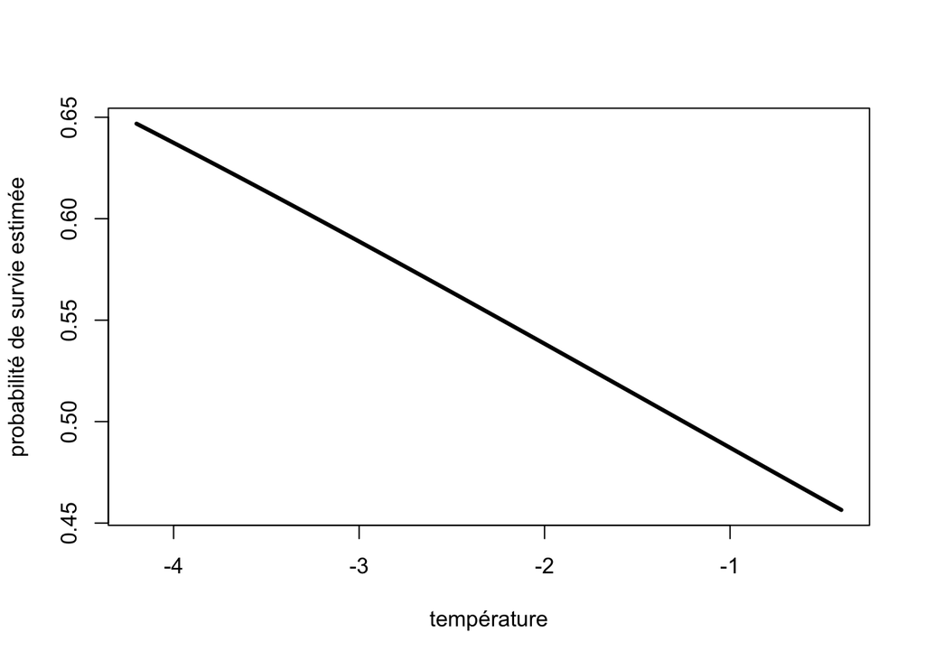

```r
plot(x = temp.values,
     y = phi.pred,
     lwd = 3,
     type = 'l',
     xlab = "température",
     ylab = "probabilité de survie estimée")
```

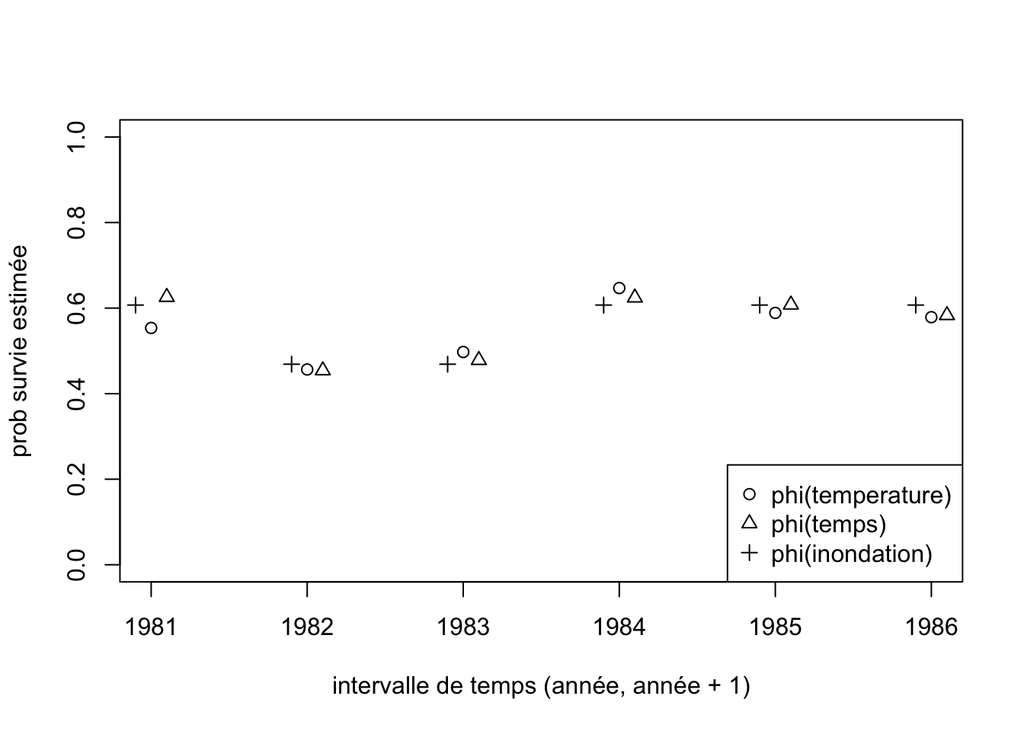

```r
plot(x = 1981:1986,
     y = phicov.cincle$results$real[1:6, 1],
     ylim = c(0,1),
     xlab = "intervalle de temps (année, année + 1)",
     ylab = "prob survie estimée",
     pch = 1)
points(x = 1981:1986 + 0.1,
     y = phitp.cincle$results$real[1:6, 1],
     pch = 2)
points(x = 1981:1986 - 0.1,
     y = c(phiinondationp.cincle$results$real[1,1], # pas inondation
           phiinondationp.cincle$results$real[2,1], # inondation
           phiinondationp.cincle$results$real[2,1], # inondation
           phiinondationp.cincle$results$real[1,1], # pas inondation
           phiinondationp.cincle$results$real[1,1], # pas inondation
           phiinondationp.cincle$results$real[1,1]), # pas inondation
     pch = 3)
legend("bottomright",
       legend = c("phi(temperature)",
                  "phi(temps)",
                  "phi(inondation)"),
       pch = c(1,2,3))
```

## 1.3 Effet de l’âge

On définit l’effet âge (temps écoulé depuis la première capture).

```r
phi.age <- list(formula =~ age)
```

On ajuste le modèle.

```r
phiage.cincle <- mark(cincle.proc,
                      cincle.ddl,
                      model.parameters = list(Phi = phi.age,
                                              p = p))
```

```
##
## Output summary for CJS model
## Name : Phi(~age)p(~1)
##
## Npar :  7  (unadjusted=6)
## -2lnL:  662.8206
## AICc :  677.0885  (unadjusted=675.02107)
##
## Beta
##                    estimate           se           lcl          ucl
## Phi:(Intercept)   0.2052283    0.1393355    -0.0678692    0.4783258
## Phi:age1          0.0214752    0.2537615    -0.4758973    0.5188477
## Phi:age2          0.3587486    0.3690997    -0.3646868    1.0821841
## Phi:age3         -0.0576631    0.5381903    -1.1125162    0.9971900
## Phi:age4          0.2395548    0.8866487    -1.4982767    1.9773863
## Phi:age5        -16.4881160 2444.5036000 -4807.7153000 4774.7390000
## p:(Intercept)     2.2552274    0.3288434     1.6106943    2.8997605
##
##
## Real Parameter Phi
##
##           1         2         3         4         5            6
## 1 0.5511278 0.5564344 0.6373722 0.5368245 0.6093982 8.480697e-08
## 2           0.5511278 0.5564344 0.6373722 0.5368245 6.093982e-01
## 3                     0.5511278 0.5564344 0.6373722 5.368245e-01
## 4                               0.5511278 0.5564344 6.373722e-01
## 5                                         0.5511278 5.564344e-01
## 6                                                   5.511278e-01
##
##
## Real Parameter p
##
##           2         3         4         5         6         7
## 1 0.9051005 0.9051005 0.9051005 0.9051005 0.9051005 0.9051005
## 2           0.9051005 0.9051005 0.9051005 0.9051005 0.9051005
## 3                     0.9051005 0.9051005 0.9051005 0.9051005
## 4                               0.9051005 0.9051005 0.9051005
## 5                                         0.9051005 0.9051005
## 6                                                   0.9051005
```

La sélection de modèles.

```r
collect.models()
```

```
##                   model npar     AICc DeltaAICc       weight Deviance
## 4 Phi(~Inondation)p(~1)    3 666.1596  0.000000 0.5186813025 51.42300
## 3       Phi(~temp)p(~1)    3 666.5896  0.430000 0.4183379647 51.85299
## 5          Phi(~1)p(~1)    2 670.8660  4.706387 0.0493084889 58.15788
## 7       Phi(~time)p(~1)    7 673.9980  7.838391 0.0102994898 51.05031
## 2        Phi(~age)p(~1)    7 677.0885 10.928891 0.0021964543 54.14081
## 6       Phi(~1)p(~time)    7 678.7481 12.588471 0.0009579635 55.80039
## 1    Phi(~time)p(~time)   12 681.7057 15.546016 0.0002183364 48.27043
```

Les paramètres estimés.

```r
phiage.cincle$results$real
```

|  | estimate | se | lcl | ucl | fixed | note |
| --- | --- | --- | --- | --- | --- | --- |
| Phi g1 c1 a0 t1 | 5.511278e-01 | 0.0344696000 | 4.830392e-01 | 0.6173525 |  |  |
| Phi g1 c1 a1 t2 | 5.564344e-01 | 0.0502658000 | 4.569903e-01 | 0.6515529 |  |  |
| Phi g1 c1 a2 t3 | 6.373722e-01 | 0.0794809000 | 4.725202e-01 | 0.7752129 |  |  |
| Phi g1 c1 a3 t4 | 5.368245e-01 | 0.1293734000 | 2.947855e-01 | 0.7626719 |  |  |
| Phi g1 c1 a4 t5 | 6.093982e-01 | 0.2089619000 | 2.182578e-01 | 0.8971004 |  |  |
| Phi g1 c1 a5 t6 | 8.480697e-08 | 0.0002073109 | 4.717545e-316 | 1.0000000 |  |  |
| p g1 c1 a1 t2 | 9.051005e-01 | 0.0282455000 | 8.335078e-01 | 0.9478346 |  |  |

Ici l’effet d’âge est plein, autrement dit on estime une probabilité de survie pour chaque classe d’âge. On peut contraindre cet effet à un effet jeune (survie qui dure une année de 0 à 1 an) vs. adulte (la même survie pour les individus au-delà d’1 an).

Pour ce faire, on ajoute une variable ageclass.

```r
# create 0, 1+ age variable
cincle.ddl <- add.design.data(cincle.proc,
                              cincle.ddl,
                             "Phi",
                             type = "age",
                             bins = c(0, 1, 7), # 2 classes d'âge
                             name = "ageclass",
                             right = FALSE)
```

Jetons un coup d’oeil.

```r
cincle.ddl$Phi
```

|  | par.index | model.index | group | cohort | age | time | occ.cohort | Cohort | Age | Time | Inondation | temp | ageclass |
| --- | --- | --- | --- | --- | --- | --- | --- | --- | --- | --- | --- | --- | --- |
| 1 | 1 | 1 | 1 | 1 | 0 | 1 | 1 | 0 | 0 | 0 | 0 | -2.3 | [0,1) |
| 2 | 2 | 2 | 1 | 1 | 1 | 2 | 1 | 0 | 1 | 1 | 1 | -0.4 | [1,7] |
| 3 | 3 | 3 | 1 | 1 | 2 | 3 | 1 | 0 | 2 | 2 | 1 | -1.2 | [1,7] |
| 4 | 4 | 4 | 1 | 1 | 3 | 4 | 1 | 0 | 3 | 3 | 0 | -4.2 | [1,7] |
| 5 | 5 | 5 | 1 | 1 | 4 | 5 | 1 | 0 | 4 | 4 | 0 | -3.0 | [1,7] |
| 6 | 6 | 6 | 1 | 1 | 5 | 6 | 1 | 0 | 5 | 5 | 0 | -2.8 | [1,7] |
| 7 | 7 | 7 | 1 | 2 | 0 | 2 | 2 | 1 | 0 | 1 | 1 | -0.4 | [0,1) |
| 8 | 8 | 8 | 1 | 2 | 1 | 3 | 2 | 1 | 1 | 2 | 1 | -1.2 | [1,7] |
| 9 | 9 | 9 | 1 | 2 | 2 | 4 | 2 | 1 | 2 | 3 | 0 | -4.2 | [1,7] |
| 10 | 10 | 10 | 1 | 2 | 3 | 5 | 2 | 1 | 3 | 4 | 0 | -3.0 | [1,7] |

[output cut: 11 more lines]

On spécifie une survie qui dépend de l’âge.

```r
phi.age2 <- list(formula=~ageclass) # age effect on survival
```

On ajuste le modèle avec survie âge-dépendante et prob de recapture constante.

```r
phiage2.cincle <- mark(cincle.proc,
                        cincle.ddl,
                        model.parameters = list(Phi = phi.age2, p = p))
```

```
##
## Output summary for CJS model
## Name : Phi(~ageclass)p(~1)
##
## Npar :  3
## -2lnL:  666.6804
## AICc :  672.7373
##
## Beta
##                    estimate        se        lcl       ucl
## Phi:(Intercept)   0.2041822 0.1390053 -0.0682681 0.4766325
## Phi:ageclass[1,7] 0.0841952 0.2119782 -0.3312821 0.4996725
## p:(Intercept)     2.2456920 0.3285355  1.6017623 2.8896216
##
##
## Real Parameter Phi
##
##           1         2         3         4         5         6
## 1 0.5508689 0.5715988 0.5715988 0.5715988 0.5715988 0.5715988
## 2           0.5508689 0.5715988 0.5715988 0.5715988 0.5715988
## 3                     0.5508689 0.5715988 0.5715988 0.5715988
## 4                               0.5508689 0.5715988 0.5715988
## 5                                         0.5508689 0.5715988
## 6                                                   0.5508689
##
##
## Real Parameter p
##
##           2         3         4         5         6         7
## 1 0.9042783 0.9042783 0.9042783 0.9042783 0.9042783 0.9042783
## 2           0.9042783 0.9042783 0.9042783 0.9042783 0.9042783
## 3                     0.9042783 0.9042783 0.9042783 0.9042783
## 4                               0.9042783 0.9042783 0.9042783
## 5                                         0.9042783 0.9042783
## 6                                                   0.9042783
```

```r
phiage2.cincle$results$real
```

|  | estimate | se | lcl | ucl | fixed | note |
| --- | --- | --- | --- | --- | --- | --- |
| Phi g1 c1 a0 t1 | 0.5508689 | 0.0343916 | 0.4829396 | 0.6169524 |  |  |
| Phi g1 c1 a1 t2 | 0.5715988 | 0.0380167 | 0.4960218 | 0.6439770 |  |  |
| p g1 c1 a1 t2 | 0.9042783 | 0.0284377 | 0.8322645 | 0.9473310 |  |  |

Que donne la sélection de modèles?

```r
collect.models()
```

```
##                   model npar     AICc DeltaAICc       weight Deviance
## 5 Phi(~Inondation)p(~1)    3 666.1596  0.000000 0.5088373938 51.42300
## 4       Phi(~temp)p(~1)    3 666.5896  0.430000 0.4103984444 51.85299
## 6          Phi(~1)p(~1)    2 670.8660  4.706387 0.0483726768 58.15788
## 3   Phi(~ageclass)p(~1)    3 672.7373  6.577620 0.0189787229 58.00061
## 8       Phi(~time)p(~1)    7 673.9980  7.838391 0.0101040186 51.05031
## 2        Phi(~age)p(~1)    7 677.0885 10.928891 0.0021547684 54.14081
## 7       Phi(~1)p(~time)    7 678.7481 12.588471 0.0009397825 55.80039
## 1    Phi(~time)p(~time)   12 681.7057 15.546016 0.0002141926 48.27043
```

# 2 Partie 2 : Estimation de la survie, exemple du martinet noir

On remet les compteurs à 0.

```r
rm(list = ls())
```

Les données.

```r
martinet <- convert.inp("dat/martinet-noir.inp",
                        group.df = data.frame(colonie = c("nord", "sud")),
                        covariates = NULL)
head(martinet)
```

|  | ch | freq | colonie |
| --- | --- | --- | --- |
| 1:1 | 00000001 | 7 | nord |
| 1:2 | 00000010 | 6 | nord |
| 1:3 | 00000011 | 1 | nord |
| 1:4 | 00000100 | 1 | nord |
| 1:8 | 00001000 | 1 | nord |
| 1:9 | 00001110 | 1 | nord |

On prépare les données.

```r
martinet.proc <- process.data(martinet,
                              begin.time = 1,
                              model = "CJS",
                              groups = ("colonie"))
martinet.ddl <- make.design.data(martinet.proc)
```

On spécifie les effets sur les paramètres.

```r
phit <- list(formula=~time)
phi <- list(formula=~1)
pt <- list(formula=~time)
p <- list(formula=~1)
```

Fait tourner modèle CJS, et examine les paramètres estimés.

```r
cjs.martinet <- mark(martinet.proc,
                      martinet.ddl,
                      model.parameters = list(Phi = phit, p = pt))
```

```
##
## Output summary for CJS model
## Name : Phi(~time)p(~time)
##
## Npar :  14  (unadjusted=13)
## -2lnL:  354.9445
## AICc :  385.1905  (unadjusted=382.88072)
##
## Beta
##                   estimate           se           lcl          ucl
## Phi:(Intercept)  1.7439695    0.8654854     0.0476180    3.4403209
## Phi:time2       -0.9669993    1.0306476    -2.9870686    1.0530701
## Phi:time3       -0.5738979    1.1624648    -2.8523290    1.7045332
## Phi:time4       -0.8957169    1.0338550    -2.9220728    1.1306390
## Phi:time5       -0.9809812    0.9802272    -2.9022265    0.9402642
## Phi:time6       -0.6912511    1.0551084    -2.7592636    1.3767614
## Phi:time7       -1.8256785  957.9266000 -1879.3619000 1875.7105000
## p:(Intercept)    2.0030717    1.0495440    -0.0540347    4.0601780
## p:time3         -0.9689981    1.1967029    -3.3145358    1.3765396
## p:time4         -1.9340789    1.1630704    -4.2136970    0.3455391
## p:time5         -1.2041796    1.1750438    -3.5072654    1.0989063
## p:time6         -0.0882527    1.2916889    -2.6199630    2.4434575
## p:time7         -0.0861500    1.4799890    -2.9869284    2.8146285
## p:time8         -1.1127936 1712.8187000 -3358.2374000 3356.0118000
##
##
## Real Parameter Phi
## Group:colonienord
##           1         2         3         4         5         6         7
## 1 0.8511906 0.6850268 0.7631579 0.7002005 0.6820022 0.7412966 0.4795841
## 2           0.6850268 0.7631579 0.7002005 0.6820022 0.7412966 0.4795841
## 3                     0.7631579 0.7002005 0.6820022 0.7412966 0.4795841
## 4                               0.7002005 0.6820022 0.7412966 0.4795841
## 5                                         0.6820022 0.7412966 0.4795841
## 6                                                   0.7412966 0.4795841
## 7                                                             0.4795841
##
## Group:coloniesud
##           1         2         3         4         5         6         7
## 1 0.8511906 0.6850268 0.7631579 0.7002005 0.6820022 0.7412966 0.4795841
```

[output cut: 13 more lines]

```
## 3                     0.5172413 0.6897374 0.8715596 0.8717948 0.7089476
## 4                               0.6897374 0.8715596 0.8717948 0.7089476
## 5                                         0.8715596 0.8717948 0.7089476
## 6                                                   0.8717948 0.7089476
## 7                                                             0.7089476
##
## Group:coloniesud
##           2         3         4         5         6         7         8
## 1 0.8811192 0.7377049 0.5172413 0.6897374 0.8715596 0.8717948 0.7089476
## 2           0.7377049 0.5172413 0.6897374 0.8715596 0.8717948 0.7089476
## 3                     0.5172413 0.6897374 0.8715596 0.8717948 0.7089476
## 4                               0.6897374 0.8715596 0.8717948 0.7089476
## 5                                         0.8715596 0.8717948 0.7089476
## 6                                                   0.8717948 0.7089476
## 7                                                             0.7089476
```

```r
cjs.martinet$results$real
```

|  | estimate | se | lcl | ucl | fixed | note |
| --- | --- | --- | --- | --- | --- | --- |
| Phi gnord c1 a0 t1 | 0.8511906 | 0.1096269 | 5.119023e-01 | 0.9689412 |  |  |
| Phi gnord c1 a1 t2 | 0.6850268 | 0.1013890 | 4.640515e-01 | 0.8452711 |  |  |
| Phi gnord c1 a2 t3 | 0.7631579 | 0.1402703 | 4.131409e-01 | 0.9365018 |  |  |
| Phi gnord c1 a3 t4 | 0.7002005 | 0.1187097 | 4.353323e-01 | 0.8761681 |  |  |
| Phi gnord c1 a4 t5 | 0.6820022 | 0.0998051 | 4.653068e-01 | 0.8409044 |  |  |
| Phi gnord c1 a5 t6 | 0.7412966 | 0.1157331 | 4.675199e-01 | 0.9033960 |  |  |
| Phi gnord c1 a6 t7 | 0.4795841 | 239.0825200 | 5.126237e-309 | 1.0000000 |  |  |
| p gnord c1 a1 t2 | 0.8811192 | 0.1099378 | 4.864946e-01 | 0.9830464 |  |  |
| p gnord c1 a2 t3 | 0.7377049 | 0.1112487 | 4.768147e-01 | 0.8966880 |  |  |
| p gnord c1 a3 t4 | 0.5172413 | 0.1251483 | 2.863173e-01 | 0.7410289 |  |  |

[output cut: 4 more lines]

PIM pour CJS.

```r
PIMS(cjs.martinet,"Phi")
```

```
## group = colonienord
##    1  2  3  4  5  6  7
## 1  1  2  3  4  5  6  7
## 2     2  3  4  5  6  7
## 3        3  4  5  6  7
## 4           4  5  6  7
## 5              5  6  7
## 6                 6  7
## 7                    7
## group = coloniesud
##    1  2  3  4  5  6  7
## 1  1  2  3  4  5  6  7
## 2     2  3  4  5  6  7
## 3        3  4  5  6  7
## 4           4  5  6  7
## 5              5  6  7
## 6                 6  7
## 7                    7
```

Fait tourner modèle avec param constants.

```r
phip.martinet <- mark(martinet.proc,
                      martinet.ddl,
                      model.parameters = list(Phi = phi, p = p))
```

```
##
## Output summary for CJS model
## Name : Phi(~1)p(~1)
##
## Npar :  2
## -2lnL:  372.8533
## AICc :  376.9136
##
## Beta
##                  estimate        se       lcl      ucl
## Phi:(Intercept) 0.8524384 0.1753794 0.5086948 1.196182
## p:(Intercept)   0.8881232 0.2391869 0.4193169 1.356930
##
##
## Real Parameter Phi
## Group:colonienord
##           1         2         3         4         5         6         7
## 1 0.7010784 0.7010784 0.7010784 0.7010784 0.7010784 0.7010784 0.7010784
## 2           0.7010784 0.7010784 0.7010784 0.7010784 0.7010784 0.7010784
## 3                     0.7010784 0.7010784 0.7010784 0.7010784 0.7010784
## 4                               0.7010784 0.7010784 0.7010784 0.7010784
## 5                                         0.7010784 0.7010784 0.7010784
## 6                                                   0.7010784 0.7010784
## 7                                                             0.7010784
##
## Group:coloniesud
##           1         2         3         4         5         6         7
## 1 0.7010784 0.7010784 0.7010784 0.7010784 0.7010784 0.7010784 0.7010784
## 2           0.7010784 0.7010784 0.7010784 0.7010784 0.7010784 0.7010784
## 3                     0.7010784 0.7010784 0.7010784 0.7010784 0.7010784
## 4                               0.7010784 0.7010784 0.7010784 0.7010784
## 5                                         0.7010784 0.7010784 0.7010784
## 6                                                   0.7010784 0.7010784
## 7                                                             0.7010784
##
##
## Real Parameter p
## Group:colonienord
##           2         3         4         5         6         7         8
## 1 0.7085027 0.7085027 0.7085027 0.7085027 0.7085027 0.7085027 0.7085027
## 2           0.7085027 0.7085027 0.7085027 0.7085027 0.7085027 0.7085027
## 3                     0.7085027 0.7085027 0.7085027 0.7085027 0.7085027
## 4                               0.7085027 0.7085027 0.7085027 0.7085027
## 5                                         0.7085027 0.7085027 0.7085027
## 6                                                   0.7085027 0.7085027
## 7                                                             0.7085027
##
## Group:coloniesud
##           2         3         4         5         6         7         8
## 1 0.7085027 0.7085027 0.7085027 0.7085027 0.7085027 0.7085027 0.7085027
## 2           0.7085027 0.7085027 0.7085027 0.7085027 0.7085027 0.7085027
## 3                     0.7085027 0.7085027 0.7085027 0.7085027 0.7085027
## 4                               0.7085027 0.7085027 0.7085027 0.7085027
## 5                                         0.7085027 0.7085027 0.7085027
## 6                                                   0.7085027 0.7085027
## 7                                                             0.7085027
```

```r
phip.martinet$results$real
```

|  | estimate | se | lcl | ucl | fixed | note |
| --- | --- | --- | --- | --- | --- | --- |
| Phi gnord c1 a0 t1 | 0.7010784 | 0.0367538 | 0.6245005 | 0.7678449 |  |  |
| p gnord c1 a1 t2 | 0.7085027 | 0.0493985 | 0.6033198 | 0.7952602 |  |  |

PIM pour CJS.

```r
PIMS(phip.martinet,"Phi")
```

```
## group = colonienord
##    1  2  3  4  5  6  7
## 1  1  1  1  1  1  1  1
## 2     1  1  1  1  1  1
## 3        1  1  1  1  1
## 4           1  1  1  1
## 5              1  1  1
## 6                 1  1
## 7                    1
## group = coloniesud
##    1  2  3  4  5  6  7
## 1  1  1  1  1  1  1  1
## 2     1  1  1  1  1  1
## 3        1  1  1  1  1
## 4           1  1  1  1
## 5              1  1  1
## 6                 1  1
## 7                    1
```

Modèle avec 2 classes d’âge sur la survie.

```r
# create 0, 1+ age variable
martinet.ddl <- add.design.data(martinet.proc,
                                martinet.ddl, # add 2 age-class structure to design matrix
                             "Phi",
                             type = "age",
                             bins = c(0, 1, 7),
                             name = "ageclass",
                             right = FALSE)
```

On spécifie une survie qui dépend de l’âge.

```r
phi.age <- list(formula=~ageclass) # age effect on survival
```

On ajuste le modèle avec survie âge-dépendante et prob de recapture constante.

```r
CJSage.martinet <- mark(martinet.proc,
                        martinet.ddl,
                        model.parameters = list(Phi = phi.age, p = p))
```

```
##
## Output summary for CJS model
## Name : Phi(~ageclass)p(~1)
##
## Npar :  3
## -2lnL:  372.846
## AICc :  378.9672
##
## Beta
##                     estimate        se        lcl       ucl
## Phi:(Intercept)    0.8749554 0.3191401  0.2494409 1.5004700
## Phi:ageclass[1,7] -0.0339141 0.3988109 -0.8155835 0.7477553
## p:(Intercept)      0.8823122 0.2487229  0.3948153 1.3698091
##
##
## Real Parameter Phi
## Group:colonienord
##           1         2         3         4         5         6         7
## 1 0.7057758 0.6986845 0.6986845 0.6986845 0.6986845 0.6986845 0.6986845
## 2           0.7057758 0.6986845 0.6986845 0.6986845 0.6986845 0.6986845
## 3                     0.7057758 0.6986845 0.6986845 0.6986845 0.6986845
## 4                               0.7057758 0.6986845 0.6986845 0.6986845
## 5                                         0.7057758 0.6986845 0.6986845
## 6                                                   0.7057758 0.6986845
## 7                                                             0.7057758
##
## Group:coloniesud
##           1         2         3         4         5         6         7
## 1 0.7057758 0.6986845 0.6986845 0.6986845 0.6986845 0.6986845 0.6986845
## 2           0.7057758 0.6986845 0.6986845 0.6986845 0.6986845 0.6986845
## 3                     0.7057758 0.6986845 0.6986845 0.6986845 0.6986845
## 4                               0.7057758 0.6986845 0.6986845 0.6986845
## 5                                         0.7057758 0.6986845 0.6986845
## 6                                                   0.7057758 0.6986845
## 7                                                             0.7057758
##
##
## Real Parameter p
## Group:colonienord
##           2         3         4         5         6         7         8
## 1 0.7073011 0.7073011 0.7073011 0.7073011 0.7073011 0.7073011 0.7073011
## 2           0.7073011 0.7073011 0.7073011 0.7073011 0.7073011 0.7073011
## 3                     0.7073011 0.7073011 0.7073011 0.7073011 0.7073011
## 4                               0.7073011 0.7073011 0.7073011 0.7073011
## 5                                         0.7073011 0.7073011 0.7073011
## 6                                                   0.7073011 0.7073011
## 7                                                             0.7073011
##
## Group:coloniesud
##           2         3         4         5         6         7         8
## 1 0.7073011 0.7073011 0.7073011 0.7073011 0.7073011 0.7073011 0.7073011
## 2           0.7073011 0.7073011 0.7073011 0.7073011 0.7073011 0.7073011
## 3                     0.7073011 0.7073011 0.7073011 0.7073011 0.7073011
## 4                               0.7073011 0.7073011 0.7073011 0.7073011
## 5                                         0.7073011 0.7073011 0.7073011
## 6                                                   0.7073011 0.7073011
## 7                                                             0.7073011
```

```r
CJSage.martinet$results$real
```

|  | estimate | se | lcl | ucl | fixed | note |
| --- | --- | --- | --- | --- | --- | --- |
| Phi gnord c1 a0 t1 | 0.7057758 | 0.0662715 | 0.5620389 | 0.8176446 |  |  |
| Phi gnord c1 a1 t2 | 0.6986845 | 0.0463273 | 0.6010232 | 0.7811452 |  |  |
| p gnord c1 a1 t2 | 0.7073011 | 0.0514922 | 0.5974413 | 0.7973493 |  |  |

PIM pour CJS avec âge.

```r
PIMS(CJSage.martinet,"Phi")
```

```
## group = colonienord
##    1  2  3  4  5  6  7
## 1  1  2  2  2  2  2  2
## 2     1  2  2  2  2  2
## 3        1  2  2  2  2
## 4           1  2  2  2
## 5              1  2  2
## 6                 1  2
## 7                    1
## group = coloniesud
##    1  2  3  4  5  6  7
## 1  1  2  2  2  2  2  2
## 2     1  2  2  2  2  2
## 3        1  2  2  2  2
## 4           1  2  2  2
## 5              1  2  2
## 6                 1  2
## 7                    1
```

Maintenant on passe au gros modèle ${phi(a.g), p(g.t)}$, avec interaction âge et groupe sur la survie, et groupe et temps sur la recapture.

On définit les paramètres.

```r
phi.a.g <- list(formula=~ageclass*colonie) # age and colonie effect on survival
p.g.t <- list(formula=~colonie*time) # age and colonie effect on survival
```

On ajuste le modèle.

```r
gros.mod <- mark(martinet.proc,
                        martinet.ddl,
                        model.parameters = list(Phi = phi.a.g, p = p.g.t))
```

```
##
## Output summary for CJS model
## Name : Phi(~ageclass * colonie)p(~colonie * time)
##
## Npar :  18  (unadjusted=16)
## -2lnL:  340.7324
## AICc :  380.4701  (unadjusted=375.67296)
##
## Beta
##                                 estimate          se          lcl         ucl
## Phi:(Intercept)                0.1691764   0.5256388   -0.8610758   1.1994285
## Phi:ageclass[1,7]              0.4792985   0.7462029   -0.9832592   1.9418562
## Phi:coloniesud                 1.4022383   0.7054832    0.0194913   2.7849854
## Phi:ageclass[1,7]:coloniesud  -1.0377706   0.9299034   -2.8603814   0.7848402
## p:(Intercept)                 18.4592470 153.7259900 -282.8436900 319.7621900
## p:coloniesud                 -16.5398190 153.7269400 -317.8446300 284.7649900
## p:time3                      -17.5622950 153.7291600 -318.8714500 283.7468600
## p:time4                      -18.7031820 153.7281400 -320.0103400 282.6039800
## p:time5                      -19.8604170 153.7307200 -321.1726300 281.4518000
## p:time6                      -18.4125010 153.7307200 -319.7247100 282.8997100
## p:time7                       11.1425570   0.0000000   11.1425570  11.1425570
## p:time8                      -19.0795970 153.7257000 -320.3819700 282.2227800
## p:coloniesud:time3            16.6193970 153.7312100 -284.6937800 317.9325800
## p:coloniesud:time4            16.9492070 153.7297500 -284.3611100 318.2595200
## p:coloniesud:time5            19.2716470 153.7329400 -282.0449200 320.5882100
## p:coloniesud:time6            18.8393400 153.7351400 -282.4815500 320.1602300
## p:coloniesud:time7           -11.3691740   0.0000000  -11.3691740 -11.3691740
## p:coloniesud:time8            17.0446110 153.7269200 -284.2601500 318.3493700
##
##
## Real Parameter Phi
## Group:colonienord
##           1         2         3         4         5         6         7
## 1 0.5421935 0.6566667 0.6566667 0.6566667 0.6566667 0.6566667 0.6566667
## 2           0.5421935 0.6566667 0.6566667 0.6566667 0.6566667 0.6566667
## 3                     0.5421935 0.6566667 0.6566667 0.6566667 0.6566667
## 4                               0.5421935 0.6566667 0.6566667 0.6566667
## 5                                         0.5421935 0.6566667 0.6566667
## 6                                                   0.5421935 0.6566667
## 7                                                             0.5421935
```

[output cut: 17 more lines]

```
## 3             0.439317 0.1976306 0.5116844 1 0.3497019
## 4                      0.1976306 0.5116844 1 0.3497019
## 5                                0.5116844 1 0.3497019
## 6                                          1 0.3497019
## 7                                            0.3497019
##
## Group:coloniesud
##           2         3         4         5         6         7         8
## 1 0.8720746 0.7264191 0.5412691 0.7909494 0.9126371 0.8445934 0.4711425
## 2           0.7264191 0.5412691 0.7909494 0.9126371 0.8445934 0.4711425
## 3                     0.5412691 0.7909494 0.9126371 0.8445934 0.4711425
## 4                               0.7909494 0.9126371 0.8445934 0.4711425
## 5                                         0.9126371 0.8445934 0.4711425
## 6                                                   0.8445934 0.4711425
## 7                                                             0.4711425
```

```r
gros.mod$results$real
```

|  | estimate | se | lcl | ucl | fixed | note |
| --- | --- | --- | --- | --- | --- | --- |
| Phi gnord c1 a0 t1 | 0.5421935 | 1.304739e-01 | 0.2971146 | 0.7684231 |  |  |
| Phi gnord c1 a1 t2 | 0.6566667 | 1.044162e-01 | 0.4355436 | 0.8258100 |  |  |
| Phi gsud c1 a0 t1 | 0.8279852 | 6.701740e-02 | 0.6568191 | 0.9236975 |  |  |
| Phi gsud c1 a1 t2 | 0.7335956 | 5.103750e-02 | 0.6227148 | 0.8212440 |  |  |
| p gnord c1 a1 t2 | 1.0000000 | 1.479102e-06 | 0.9999971 | 1.0000029 |  |  |
| p gnord c1 a2 t3 | 0.7103228 | 2.128972e-01 | 0.2439782 | 0.9490635 |  |  |
| p gnord c1 a3 t4 | 0.4393170 | 2.616167e-01 | 0.0890189 | 0.8626888 |  |  |
| p gnord c1 a4 t5 | 0.1976306 | 1.847869e-01 | 0.0244783 | 0.7074113 |  |  |
| p gnord c1 a5 t6 | 0.5116844 | 2.865186e-01 | 0.0996798 | 0.9084022 |  |  |
| p gnord c1 a6 t7 | 1.0000000 | 0.000000e+00 | 1.0000000 | 1.0000000 |  |  |

[output cut: 8 more lines]

PIM pour survie et détection dans le gros modèle.

```r
PIMS(gros.mod,"Phi")
```

```
## group = colonienord
##    1  2  3  4  5  6  7
## 1  1  2  2  2  2  2  2
## 2     1  2  2  2  2  2
## 3        1  2  2  2  2
## 4           1  2  2  2
## 5              1  2  2
## 6                 1  2
## 7                    1
## group = coloniesud
##    1  2  3  4  5  6  7
## 1  3  4  4  4  4  4  4
## 2     3  4  4  4  4  4
## 3        3  4  4  4  4
## 4           3  4  4  4
## 5              3  4  4
## 6                 3  4
## 7                    3
```

```r
PIMS(gros.mod,"p")
```

```
## group = colonienord
##    2  3  4  5  6  7  8
## 1  5  6  7  8  9 10 11
## 2     6  7  8  9 10 11
## 3        7  8  9 10 11
## 4           8  9 10 11
## 5              9 10 11
## 6                10 11
## 7                   11
## group = coloniesud
##    2  3  4  5  6  7  8
## 1 12 13 14 15 16 17 18
## 2    13 14 15 16 17 18
## 3       14 15 16 17 18
## 4          15 16 17 18
## 5             16 17 18
## 6                17 18
## 7                   18
```

La sélection de modèles.

```r
collect.models()
```

```
##                                        model npar     AICc DeltaAICc     weight
## 4                               Phi(~1)p(~1)    2 376.9136  0.000000 0.64807823
## 2                        Phi(~ageclass)p(~1)    3 378.9672  2.053631 0.23210645
## 3 Phi(~ageclass * colonie)p(~colonie * time)   18 380.4701  3.556533 0.10948031
## 1                         Phi(~time)p(~time)   14 385.1905  8.276948 0.01033501
##   Deviance
## 4 133.6472
## 2 133.6399
## 3 101.5263
## 1 115.7384
```

# 3 Partie 3 : Hypothèses des modèles de capture-recapture, hétérogénéité et tests d’ajustement

Le but de cet exercice est de se familiariser avec les données de capture-recapture en population ouverte, d’ajuster par maximum de vraisemblance quelques modèles simples, de comparer ces modèles entre eux pour déterminer celui qui fournit la meilleure description des données et de tester la qualité de l’ajustement de ces modèles.

## 3.1 Question 1

On simule 2 jeux de données de capture-recapture avec les paramètres de survie ($\phi$) et recapture ($p$) suivants : * jeu de données G1 : $\phi = 0.8$, $p = 0.8$ ; * jeu de données G2 : $\phi = 0.8$, $p = 0.2$.

```r
simul <- function(nind, nocc, phi, p){
   dat <- matrix(0, nrow = nind, ncol = nocc)
   dat[1:nind, 1] <- 1 # a single cohort
   for (i in 1:nind){
      # processus survie
      for (j in 2:nocc){
         alive.or.dead <- rbinom(1, 1, phi)
         # conditional on being alive at t, alive or dead at t+1
         dat[i, j] <- ifelse(dat[i, j - 1] == 0, 0, alive.or.dead)
      }
      # processus detection
      for (j in 2:nocc){
         detected.or.not <- rbinom(1, 1, p)
         # conditional on being alive at t, detected or not at t
         dat[i, j] <- ifelse(dat[i, j] == 0, 0, detected.or.not)
      }
   }
data.frame(y = dat)
}
```

```r
set.seed(2021)
nind <- 500
nocc <- 8
G1 <- simul(nind = nind, nocc = nocc, phi = 0.8, p = 0.8)
G2 <- simul(nind = nind, nocc = nocc, phi = 0.8, p = 0.2)
```

Ajuster séparément à G1 et G2 le modèle ${\Phi(t), p(t)}$ appelé aussi le modèle de Cormack-Jolly-Seber (CJS). Que pouvez-vous vous dire sur l’estimation des paramètres ?

```r
G1marked <- data.frame(ch = tidyr::unite(G1, col = "ch", sep = ""),
                       n = rep(1, nrow(G1)))
G2marked <- data.frame(ch = tidyr::unite(G2, col = "ch", sep = ""),
                       n = rep(1, nrow(G2)))
```

On prépare les données.

```r
G1.proc <- process.data(G1marked)
G2.proc <- process.data(G2marked)
G1.ddl <- make.design.data(G1.proc)
G2.ddl <- make.design.data(G2.proc)
```

On spécifie les paramètres.

```r
phi <- list(formula=~1)
p <- list(formula=~1)
```

On ajuste le modèle avec paramètres constants aux données G1.

```r
cjs.G1 <- mark(G1.proc,
              G1.ddl,
              model.parameters = list(Phi = phi, p = p))
```

```
##
## Output summary for CJS model
## Name : Phi(~1)p(~1)
##
## Npar :  2
## -2lnL:  3009.594
## AICc :  3013.601
##
## Beta
##                 estimate        se      lcl      ucl
## Phi:(Intercept) 1.349691 0.0584381 1.235152 1.464229
## p:(Intercept)   1.417211 0.0761598 1.267938 1.566484
##
##
## Real Parameter Phi
##
##           1         2         3         4         5         6         7
## 1 0.7940791 0.7940791 0.7940791 0.7940791 0.7940791 0.7940791 0.7940791
## 2           0.7940791 0.7940791 0.7940791 0.7940791 0.7940791 0.7940791
## 3                     0.7940791 0.7940791 0.7940791 0.7940791 0.7940791
## 4                               0.7940791 0.7940791 0.7940791 0.7940791
## 5                                         0.7940791 0.7940791 0.7940791
## 6                                                   0.7940791 0.7940791
## 7                                                             0.7940791
##
##
## Real Parameter p
##
##           2         3         4         5         6         7         8
## 1 0.8049008 0.8049008 0.8049008 0.8049008 0.8049008 0.8049008 0.8049008
## 2           0.8049008 0.8049008 0.8049008 0.8049008 0.8049008 0.8049008
## 3                     0.8049008 0.8049008 0.8049008 0.8049008 0.8049008
## 4                               0.8049008 0.8049008 0.8049008 0.8049008
## 5                                         0.8049008 0.8049008 0.8049008
## 6                                                   0.8049008 0.8049008
## 7                                                             0.8049008
```

```r
cjs.G1$results$real
```

|  | estimate | se | lcl | ucl | fixed | note |
| --- | --- | --- | --- | --- | --- | --- |
| Phi g1 c1 a0 t1 | 0.7940791 | 0.0095556 | 0.7747191 | 0.8121787 |  |  |
| p g1 c1 a1 t2 | 0.8049008 | 0.0119598 | 0.7803896 | 0.8272818 |  |  |

Puis aux données G2.

```r
cjs.G2 <- mark(G2.proc,
              G2.ddl,
              model.parameters = list(Phi = phi, p = p))
```

```
##
## Output summary for CJS model
## Name : Phi(~1)p(~1)
##
## Npar :  2
## -2lnL:  2091.359
## AICc :  2095.374
##
## Beta
##                  estimate        se       lcl       ucl
## Phi:(Intercept)  1.487792 0.1111557  1.269926  1.705657
## p:(Intercept)   -1.398919 0.0940821 -1.583320 -1.214518
##
##
## Real Parameter Phi
##
##           1         2         3         4         5         6         7
## 1 0.8157466 0.8157466 0.8157466 0.8157466 0.8157466 0.8157466 0.8157466
## 2           0.8157466 0.8157466 0.8157466 0.8157466 0.8157466 0.8157466
## 3                     0.8157466 0.8157466 0.8157466 0.8157466 0.8157466
## 4                               0.8157466 0.8157466 0.8157466 0.8157466
## 5                                         0.8157466 0.8157466 0.8157466
## 6                                                   0.8157466 0.8157466
## 7                                                             0.8157466
##
##
## Real Parameter p
##
##           2         3         4         5         6         7         8
## 1 0.1979877 0.1979877 0.1979877 0.1979877 0.1979877 0.1979877 0.1979877
## 2           0.1979877 0.1979877 0.1979877 0.1979877 0.1979877 0.1979877
## 3                     0.1979877 0.1979877 0.1979877 0.1979877 0.1979877
## 4                               0.1979877 0.1979877 0.1979877 0.1979877
## 5                                         0.1979877 0.1979877 0.1979877
## 6                                                   0.1979877 0.1979877
## 7                                                             0.1979877
```

```r
cjs.G2$results$real
```

|  | estimate | se | lcl | ucl | fixed | note |
| --- | --- | --- | --- | --- | --- | --- |
| Phi g1 c1 a0 t1 | 0.8157466 | 0.0167072 | 0.7807302 | 0.8462721 |  |  |
| p g1 c1 a1 t2 | 0.1979877 | 0.0149392 | 0.1703258 | 0.2289026 |  |  |

## 3.2 Question 2

1. Grouper les jeux de données G1 et G2 pour obtenir le jeu de données G1+G2.

```r
G1plusG2 <- rbind(G1, G2)
```

2. Ajuster le modèle CJS à G1+G2. Que remarquez-vous concernant l’estimation des paramètres ?

```r
G1G2marked <- data.frame(ch = tidyr::unite(G1plusG2, col = "ch", sep = ""),
                         n = rep(1, nrow(G1plusG2)))
G1G2.proc <- process.data(G1G2marked)
G1G2.ddl <- make.design.data(G1G2.proc)
cjs.G1G2 <- mark(G1G2.proc,
                G1G2.ddl,
                model.parameters = list(Phi = phi, p = p))
```

```
##
## Output summary for CJS model
## Name : Phi(~1)p(~1)
##
## Npar :  2
## -2lnL:  5825.357
## AICc :  5829.362
##
## Beta
##                  estimate        se       lcl       ucl
## Phi:(Intercept) 1.1639804 0.0436060 1.0785126 1.2494483
## p:(Intercept)   0.3450607 0.0495103 0.2480206 0.4421009
##
##
## Real Parameter Phi
##
##           1         2         3         4         5         6         7
## 1 0.7620552 0.7620552 0.7620552 0.7620552 0.7620552 0.7620552 0.7620552
## 2           0.7620552 0.7620552 0.7620552 0.7620552 0.7620552 0.7620552
## 3                     0.7620552 0.7620552 0.7620552 0.7620552 0.7620552
## 4                               0.7620552 0.7620552 0.7620552 0.7620552
## 5                                         0.7620552 0.7620552 0.7620552
## 6                                                   0.7620552 0.7620552
## 7                                                             0.7620552
##
##
## Real Parameter p
##
##           2         3         4         5         6         7         8
## 1 0.5854193 0.5854193 0.5854193 0.5854193 0.5854193 0.5854193 0.5854193
## 2           0.5854193 0.5854193 0.5854193 0.5854193 0.5854193 0.5854193
## 3                     0.5854193 0.5854193 0.5854193 0.5854193 0.5854193
## 4                               0.5854193 0.5854193 0.5854193 0.5854193
## 5                                         0.5854193 0.5854193 0.5854193
## 6                                                   0.5854193 0.5854193
## 7                                                             0.5854193
```

```r
cjs.G1G2$results$real
```

|  | estimate | se | lcl | ucl | fixed | note |
| --- | --- | --- | --- | --- | --- | --- |
| Phi g1 c1 a0 t1 | 0.7620552 | 0.0079070 | 0.7462124 | 0.7772043 |  |  |
| p g1 c1 a1 t2 | 0.5854193 | 0.0120163 | 0.5616892 | 0.6087595 |  |  |

Modèle avec survie qui dépend du temps.

```r
phi.time <- list(formula=~time)
cjs.G1G2 <- mark(G1G2.proc,
                G1G2.ddl,
                model.parameters = list(Phi = phi.time, p = p))
```

```
##
## Output summary for CJS model
## Name : Phi(~time)p(~1)
##
## Npar :  8
## -2lnL:  5792.723
## AICc :  5808.782
##
## Beta
##                  estimate        se        lcl       ucl
## Phi:(Intercept) 0.7598161 0.0909050  0.5816422 0.9379900
## Phi:time2       0.3979968 0.1933474  0.0190358 0.7769578
## Phi:time3       0.7072559 0.2137484  0.2883091 1.1262027
## Phi:time4       0.6334187 0.2291568  0.1842713 1.0825662
## Phi:time5       0.4558445 0.2336745 -0.0021575 0.9138466
## Phi:time6       0.8182697 0.3428343  0.1463145 1.4902250
## Phi:time7       1.0221803 0.5473035 -0.0505346 2.0948952
## p:(Intercept)   0.3870597 0.0505148  0.2880506 0.4860687
##
##
## Real Parameter Phi
##
##           1         2         3         4        5         6         7
## 1 0.6813138 0.7609351 0.8126119 0.8011082 0.771299 0.8289333 0.8559432
## 2           0.7609351 0.8126119 0.8011082 0.771299 0.8289333 0.8559432
## 3                     0.8126119 0.8011082 0.771299 0.8289333 0.8559432
## 4                               0.8011082 0.771299 0.8289333 0.8559432
## 5                                         0.771299 0.8289333 0.8559432
## 6                                                  0.8289333 0.8559432
## 7                                                            0.8559432
##
##
## Real Parameter p
##
##           2         3         4         5         6         7         8
## 1 0.5955747 0.5955747 0.5955747 0.5955747 0.5955747 0.5955747 0.5955747
## 2           0.5955747 0.5955747 0.5955747 0.5955747 0.5955747 0.5955747
## 3                     0.5955747 0.5955747 0.5955747 0.5955747 0.5955747
## 4                               0.5955747 0.5955747 0.5955747 0.5955747
## 5                                         0.5955747 0.5955747 0.5955747
## 6                                                   0.5955747 0.5955747
## 7                                                             0.5955747
```

```r
cjs.G1G2$results$real
```

|  | estimate | se | lcl | ucl | fixed | note |
| --- | --- | --- | --- | --- | --- | --- |
| Phi g1 c1 a0 t1 | 0.6813138 | 0.0197378 | 0.6414452 | 0.7186935 |  |  |
| Phi g1 c1 a1 t2 | 0.7609351 | 0.0259835 | 0.7063779 | 0.8081089 |  |  |
| Phi g1 c1 a2 t3 | 0.8126119 | 0.0294916 | 0.7479048 | 0.8637363 |  |  |
| Phi g1 c1 a3 t4 | 0.8011082 | 0.0335598 | 0.7271892 | 0.8588852 |  |  |
| Phi g1 c1 a4 t5 | 0.7712990 | 0.0379757 | 0.6886254 | 0.8372109 |  |  |
| Phi g1 c1 a5 t6 | 0.8289333 | 0.0470411 | 0.7166458 | 0.9027612 |  |  |
| Phi g1 c1 a6 t7 | 0.8559432 | 0.0668937 | 0.6723162 | 0.9450759 |  |  |
| p g1 c1 a1 t2 | 0.5955747 | 0.0121673 | 0.5715188 | 0.6191799 |  |  |

## 3.3 Question 3

A l’aide du package `R2ucare`, tester la qualité de l’ajustement du modèle CJS aux données G1, G2 et G1+G2. Quelles sont vos conclusions ?

G1

```r
overall_CJS(G1, rep(1,nrow(G1)))
```

|  | chi2 | degree_of_freedom | p_value |
| --- | --- | --- | --- |
| Gof test for CJS model: | 3.327 | 9 | 0.95 |

G2

```r
overall_CJS(G2, rep(1,nrow(G2)))
```

|  | chi2 | degree_of_freedom | p_value |
| --- | --- | --- | --- |
| Gof test for CJS model: | 15.041 | 14 | 0.375 |

G1G2

```r
overall_CJS(G1plusG2, rep(1,nrow(G1plusG2)))
```

|  | chi2 | degree_of_freedom | p_value |
| --- | --- | --- | --- |
| Gof test for CJS model: | 150.342 | 15 | 0 |

## 3.4 Question 4

Il peut y avoir des animaux en transit sur la zone d’étude.

1. Pour créer artificiellement une telle situation, rajouter 50 individus en transit (i.e. possédant une histoire avec un seul événement de capture) à chaque date dans G1.

```r
G1transit <- as.matrix(G1)
ntransients <- 50
for (j in 1:nocc){
   zeros <- matrix(0, nrow = ntransients, ncol = nocc)
   zeros[, j] <- 1
   G1transit <- rbind(G1transit, zeros)
}
G1transit <- data.frame(y = G1transit)
```

```r
dim(G1transit)
```

```
## [1] 900   8
```

```r
head(G1transit)
```

|  | y.y.1 | y.y.2 | y.y.3 | y.y.4 | y.y.5 | y.y.6 | y.y.7 | y.y.8 |
| --- | --- | --- | --- | --- | --- | --- | --- | --- |
| 1 | 1 | 1 | 0 | 0 | 1 | 0 | 1 | 1 |
| 2 | 1 | 0 | 0 | 0 | 0 | 0 | 0 | 0 |
| 3 | 1 | 0 | 0 | 0 | 0 | 0 | 0 | 0 |
| 4 | 1 | 0 | 0 | 0 | 0 | 0 | 0 | 0 |
| 5 | 1 | 1 | 0 | 0 | 0 | 0 | 0 | 0 |
| 6 | 1 | 1 | 1 | 0 | 0 | 0 | 0 | 0 |

```r
tail(G1transit)
```

|  | y.y.1 | y.y.2 | y.y.3 | y.y.4 | y.y.5 | y.y.6 | y.y.7 | y.y.8 |
| --- | --- | --- | --- | --- | --- | --- | --- | --- |
| 895 | 0 | 0 | 0 | 0 | 0 | 0 | 0 | 1 |
| 896 | 0 | 0 | 0 | 0 | 0 | 0 | 0 | 1 |
| 897 | 0 | 0 | 0 | 0 | 0 | 0 | 0 | 1 |
| 898 | 0 | 0 | 0 | 0 | 0 | 0 | 0 | 1 |
| 899 | 0 | 0 | 0 | 0 | 0 | 0 | 0 | 1 |
| 900 | 0 | 0 | 0 | 0 | 0 | 0 | 0 | 1 |

2. Faire tourner le modèle CJS à ces nouvelles données avec `RMark`. Quelles sont vos conclusions concernant les estimations ?

```r
G1transitmarked <- data.frame(ch = tidyr::unite(G1transit, col = "ch", sep = ""),
                              n = rep(1, nrow(G1transit)))
```

```r
G1transit.proc <- process.data(G1transitmarked)
G1transit.ddl <- make.design.data(G1transit.proc)
```

Ajuste le modèle.

```r
cjs.G1transit <- mark(G1transit.proc,
                     G1transit.ddl,
                     model.parameters = list(Phi = phi, p = p))
```

```
##
## Output summary for CJS model
## Name : Phi(~1)p(~1)
##
## Npar :  2
## -2lnL:  3793.282
## AICc :  3797.288
##
## Beta
##                  estimate        se       lcl      ucl
## Phi:(Intercept) 0.7871844 0.0479482 0.6932058 0.881163
## p:(Intercept)   1.1885540 0.0770665 1.0375037 1.339604
##
##
## Real Parameter Phi
##
##           1         2         3         4         5         6         7
## 1 0.6872264 0.6872264 0.6872264 0.6872264 0.6872264 0.6872264 0.6872264
## 2           0.6872264 0.6872264 0.6872264 0.6872264 0.6872264 0.6872264
## 3                     0.6872264 0.6872264 0.6872264 0.6872264 0.6872264
## 4                               0.6872264 0.6872264 0.6872264 0.6872264
## 5                                         0.6872264 0.6872264 0.6872264
## 6                                                   0.6872264 0.6872264
## 7                                                             0.6872264
##
##
## Real Parameter p
##
##           2         3         4         5         6         7         8
## 1 0.7664823 0.7664823 0.7664823 0.7664823 0.7664823 0.7664823 0.7664823
## 2           0.7664823 0.7664823 0.7664823 0.7664823 0.7664823 0.7664823
## 3                     0.7664823 0.7664823 0.7664823 0.7664823 0.7664823
## 4                               0.7664823 0.7664823 0.7664823 0.7664823
## 5                                         0.7664823 0.7664823 0.7664823
## 6                                                   0.7664823 0.7664823
## 7                                                             0.7664823
```

```r
cjs.G1transit$results$real
```

|  | estimate | se | lcl | ucl | fixed | note |
| --- | --- | --- | --- | --- | --- | --- |
| Phi g1 c1 a0 t1 | 0.6872264 | 0.0103063 | 0.6666797 | 0.7070632 |  |  |
| p g1 c1 a1 t2 | 0.7664823 | 0.0137939 | 0.7383680 | 0.7924249 |  |  |

Idem avec survie qui dépend du temps.

```r
cjs.G1transit <- mark(G1transit.proc,
                     G1transit.ddl,
                     model.parameters = list(Phi = phi.time, p = p))
```

```
##
## Output summary for CJS model
## Name : Phi(~time)p(~1)
##
## Npar :  8
## -2lnL:  3776.066
## AICc :  3792.138
##
## Beta
##                   estimate        se        lcl        ucl
## Phi:(Intercept)  1.1097470 0.1223382  0.8699640  1.3495299
## Phi:time2       -0.3581902 0.1908888 -0.7323322  0.0159519
## Phi:time3       -0.2686692 0.1890298 -0.6391676  0.1018291
## Phi:time4       -0.4461150 0.1934616 -0.8252997 -0.0669302
## Phi:time5       -0.4810593 0.2040145 -0.8809277 -0.0811909
## Phi:time6       -0.3850169 0.2250949 -0.8262028  0.0561690
## Phi:time7       -0.8490584 0.2307666 -1.3013610 -0.3967558
## p:(Intercept)    1.1866979 0.0786387  1.0325661  1.3408297
##
##
## Real Parameter Phi
##
##           1         2         3         4         5         6         7
## 1 0.7520819 0.6795178 0.6986921 0.6600758 0.6521918 0.6736478 0.5648055
## 2           0.6795178 0.6986921 0.6600758 0.6521918 0.6736478 0.5648055
## 3                     0.6986921 0.6600758 0.6521918 0.6736478 0.5648055
## 4                               0.6600758 0.6521918 0.6736478 0.5648055
## 5                                         0.6521918 0.6736478 0.5648055
## 6                                                   0.6736478 0.5648055
## 7                                                             0.5648055
##
##
## Real Parameter p
##
##         2       3       4       5       6       7       8
## 1 0.76615 0.76615 0.76615 0.76615 0.76615 0.76615 0.76615
## 2         0.76615 0.76615 0.76615 0.76615 0.76615 0.76615
## 3                 0.76615 0.76615 0.76615 0.76615 0.76615
## 4                         0.76615 0.76615 0.76615 0.76615
## 5                                 0.76615 0.76615 0.76615
## 6                                         0.76615 0.76615
## 7                                                 0.76615
```

```r
cjs.G1transit$results$real
```

|  | estimate | se | lcl | ucl | fixed | note |
| --- | --- | --- | --- | --- | --- | --- |
| Phi g1 c1 a0 t1 | 0.7520819 | 0.0228105 | 0.7047382 | 0.7940528 |  |  |
| Phi g1 c1 a1 t2 | 0.6795178 | 0.0270283 | 0.6244073 | 0.7300382 |  |  |
| Phi g1 c1 a2 t3 | 0.6986921 | 0.0305397 | 0.6356994 | 0.7549907 |  |  |
| Phi g1 c1 a3 t4 | 0.6600758 | 0.0337817 | 0.5911055 | 0.7228668 |  |  |
| Phi g1 c1 a4 t5 | 0.6521918 | 0.0371981 | 0.5762202 | 0.7211352 |  |  |
| Phi g1 c1 a5 t6 | 0.6736478 | 0.0419754 | 0.5867403 | 0.7500641 |  |  |
| Phi g1 c1 a6 t7 | 0.5648055 | 0.0489543 | 0.4676276 | 0.6572467 |  |  |
| p g1 c1 a1 t2 | 0.7661500 | 0.0140892 | 0.7374131 | 0.7926264 |  |  |

3. Tester l’ajustement du modèle CJS à ces mêmes données avec `R2ucare`. Interpréter en particulier la composante 3.SR du test.

```r
overall_CJS(G1transit, rep(1,nrow(G1transit)))
```

|  | chi2 | degree_of_freedom | p_value |
| --- | --- | --- | --- |
| Gof test for CJS model: | 543.606 | 15 | 0 |

```r
test2ct(G1transit, rep(1,nrow(G1transit)))
```

```
## $test2ct
##      stat        df     p_val sign_test
##     1.135     5.000     0.951     0.600
##
## $details
##   component dof  stat p_val signed_test  test_perf
## 1         2   1 0.112 0.737      -0.335 Chi-square
## 2         3   1 0.003 0.953       0.055 Chi-square
## 3         4   1 0.721 0.396       0.849 Chi-square
## 4         5   1 0.139 0.709       0.373 Chi-square
## 5         6   1  0.16  0.69         0.4     Fisher
```

```r
test3sr(G1transit, rep(1,nrow(G1transit)))
```

```
## $test3sr
##      stat        df     p_val sign_test
##   540.279     6.000     0.000    23.140
##
## $details
##   component    stat p_val signed_test  test_perf
## 1         2  96.827     0        9.84 Chi-square
## 2         3 103.329     0      10.165 Chi-square
## 3         4  88.333     0       9.399 Chi-square
## 4         5   94.62     0       9.727 Chi-square
## 5         6 100.743     0      10.037 Chi-square
## 6         7  56.427     0       7.512 Chi-square
```

4. Faire tourner un modèle à 2 classes d’âge sur la survie $\phi(a2*t)$ avec `RMark`. Vos conclusions ?

```r
G1transit.ddl <- make.design.data(G1transit.proc)
# create 0, 1+ age variable
G1transit.ddl <- add.design.data(G1transit.proc,
                             G1transit.ddl, # add 2 age-class structure to design matrix
                             "Phi",
                             type = "age",
                             bins = c(0, 1, nocc - 1),
                             name = "ageclass",
                             right = FALSE)
```

On spécifie une survie qui dépend de l’âge.

```r
phi.age <- list(formula=~ageclass) # age effect on survival
```

On ajuste le modèle.

```r
cjsage.G1transit <- mark(G1transit.proc,
                     G1transit.ddl,
                     model.parameters = list(Phi = phi.age, p = p))
```

```
##
## Output summary for CJS model
## Name : Phi(~ageclass)p(~1)
##
## Npar :  3
## -2lnL:  3604.772
## AICc :  3610.784
##
## Beta
##                     estimate        se        lcl       ucl
## Phi:(Intercept)   -0.1000537 0.0738121 -0.2447254 0.0446179
## Phi:ageclass[1,7]  1.4656702 0.1046905  1.2604768 1.6708635
## p:(Intercept)      1.3783584 0.0769186  1.2275979 1.5291189
##
##
## Real Parameter Phi
##
##           1         2         3         4         5         6         7
## 1 0.4750074 0.7966710 0.7966710 0.7966710 0.7966710 0.7966710 0.7966710
## 2           0.4750074 0.7966710 0.7966710 0.7966710 0.7966710 0.7966710
## 3                     0.4750074 0.7966710 0.7966710 0.7966710 0.7966710
## 4                               0.4750074 0.7966710 0.7966710 0.7966710
## 5                                         0.4750074 0.7966710 0.7966710
## 6                                                   0.4750074 0.7966710
## 7                                                             0.4750074
##
##
## Real Parameter p
##
##           2         3         4         5         6         7         8
## 1 0.7987272 0.7987272 0.7987272 0.7987272 0.7987272 0.7987272 0.7987272
## 2           0.7987272 0.7987272 0.7987272 0.7987272 0.7987272 0.7987272
## 3                     0.7987272 0.7987272 0.7987272 0.7987272 0.7987272
## 4                               0.7987272 0.7987272 0.7987272 0.7987272
## 5                                         0.7987272 0.7987272 0.7987272
## 6                                                   0.7987272 0.7987272
## 7                                                             0.7987272
```

```r
cjsage.G1transit$results$real
```

|  | estimate | se | lcl | ucl | fixed | note |
| --- | --- | --- | --- | --- | --- | --- |
| Phi g1 c1 a0 t1 | 0.4750074 | 0.0184069 | 0.4391222 | 0.5111526 |  |  |
| Phi g1 c1 a1 t2 | 0.7966710 | 0.0113847 | 0.7734445 | 0.8180764 |  |  |
| p g1 c1 a1 t2 | 0.7987272 | 0.0123656 | 0.7733979 | 0.8218774 |  |  |

D’une autre façon.

```r
G1transit.ddl <- make.design.data(G1transit.proc)
#max age 4
G1transit.ddl$Phi$max.age <- as.factor((G1transit.ddl$Phi$Age < 1) * G1transit.ddl$Phi$Age + (G1transit.ddl$Phi$Age>0) * 1)
phi.max.age <- list(formula=~max.age)
cjsaget.G1transit <- mark(G1transit.proc,
                     G1transit.ddl,
                     model.parameters = list(Phi = phi.max.age, p = p))
```

```
##
## Output summary for CJS model
## Name : Phi(~max.age)p(~1)
##
## Npar :  3
## -2lnL:  3604.772
## AICc :  3610.784
##
## Beta
##                   estimate        se        lcl      ucl
## Phi:(Intercept) -0.1000536 0.0738121 -0.2447253 0.044618
## Phi:max.age1     1.4656700 0.1046905  1.2604766 1.670863
## p:(Intercept)    1.3783584 0.0769186  1.2275979 1.529119
##
##
## Real Parameter Phi
##
##           1         2         3         4         5         6         7
## 1 0.4750074 0.7966710 0.7966710 0.7966710 0.7966710 0.7966710 0.7966710
## 2           0.4750074 0.7966710 0.7966710 0.7966710 0.7966710 0.7966710
## 3                     0.4750074 0.7966710 0.7966710 0.7966710 0.7966710
## 4                               0.4750074 0.7966710 0.7966710 0.7966710
## 5                                         0.4750074 0.7966710 0.7966710
## 6                                                   0.4750074 0.7966710
## 7                                                             0.4750074
##
##
## Real Parameter p
##
##           2         3         4         5         6         7         8
## 1 0.7987272 0.7987272 0.7987272 0.7987272 0.7987272 0.7987272 0.7987272
## 2           0.7987272 0.7987272 0.7987272 0.7987272 0.7987272 0.7987272
## 3                     0.7987272 0.7987272 0.7987272 0.7987272 0.7987272
## 4                               0.7987272 0.7987272 0.7987272 0.7987272
## 5                                         0.7987272 0.7987272 0.7987272
## 6                                                   0.7987272 0.7987272
## 7                                                             0.7987272
```

```r
PIMS(cjsaget.G1transit,"Phi")
```

```
## group = Group 1
##    1  2  3  4  5  6  7
## 1  1  2  2  2  2  2  2
## 2     1  2  2  2  2  2
## 3        1  2  2  2  2
## 4           1  2  2  2
## 5              1  2  2
## 6                 1  2
## 7                    1
```

```r
cjsaget.G1transit$results$real
```

|  | estimate | se | lcl | ucl | fixed | note |
| --- | --- | --- | --- | --- | --- | --- |
| Phi g1 c1 a0 t1 | 0.4750074 | 0.0184069 | 0.4391222 | 0.5111527 |  |  |
| Phi g1 c1 a1 t2 | 0.7966710 | 0.0113847 | 0.7734445 | 0.8180764 |  |  |
| p g1 c1 a1 t2 | 0.7987272 | 0.0123656 | 0.7733979 | 0.8218774 |  |  |

Supprime fichiers créés en cours de route.

```r
cleanup(ask = FALSE)
```